# Sparkling project 1

```python
## Test Data

rmse_model5_test_1 = metrics.mean_squared_error(SES_test['Sparkling'],SES_test['predict'],squared=False)
print("For Alpha =0.995 Simple Exponential Smoothing Model forecast on the Test Data, RMSE is %3.3f" %(rmse_model5_test_1))
```

```
For Alpha =0.995 Simple Exponential Smoothing Model forecast on the Test Data, RMSE is 1316.035
```

```python
resultsDf_5 = pd.DataFrame({'Test RMSE': [rmse_model5_test_1]},index=['Alpha=0.995,SimpleExponentialSmoothing'])

resultsDf = pd.concat([resultsDf, resultsDf_5])
resultsDf
```

|  | Test RMSE |
| --- | --- |
| RegressionOnTime | 1389.135175 |
| NaiveModel | 3864.279352 |
| SimpleAverageModel | 1275.081804 |
| 2pointTrailingMovingAverage | 813.400684 |
| 4pointTrailingMovingAverage | 1156.589694 |
| 6pointTrailingMovingAverage | 1283.927428 |
| 9pointTrailingMovingAverage | 1346.278315 |
| Alpha=0.995,SimpleExponentialSmoothing | 1316.035487 |

#### Setting different alpha values

Remember, the higher the alpha value more weightage is given to the more recent observation. That means, what happened recently will happen again.

```python
## First we will define an empty dataframe to store our values from the loop

resultsDf_6 = pd.DataFrame({'Alpha Values':[],'Train RMSE':[],'Test RMSE': []})
resultsDf_6
```

|  | Alpha Values | Train RMSE | Test RMSE |
| --- | --- | --- | --- |

```python
for i in np.arange(0.3,1,0.1):
    model_SES_alpha_i = model_SES.fit(smoothing_level=i,optimized=False,use_brute=True)
    SES_train['predict',i] = model_SES_alpha_i.fittedvalues
    SES_test['predict',i] = model_SES_alpha_i.forecast(steps=55)

    rmse_model5_train_i = metrics.mean_squared_error(SES_train['Sparkling'],SES_train['predict',i],squared=False)

    rmse_model5_test_i = metrics.mean_squared_error(SES_test['Sparkling'],SES_test['predict',i],squared=False)

    resultsDf_6 = resultsDf_6.append({'Alpha Values':i,'Train RMSE':rmse_model5_train_i
                                      ,'Test RMSE':rmse_model5_test_i}, ignore_index=True)
```

#### Model Evaluation:

```python
resultsDf_6.sort_values(by=['Test RMSE'],ascending=True)
```

|  | Alpha Values | Train RMSE | Test RMSE |
| --- | --- | --- | --- |
| 0 | 0.3 | 1359.511747 | 1935.507132 |
| 1 | 0.4 | 1352.588879 | 2311.919615 |
| 2 | 0.5 | 1344.004369 | 2666.351413 |
| 3 | 0.6 | 1338.805381 | 2979.204388 |
| 4 | 0.7 | 1338.844308 | 3249.944092 |
| 5 | 0.8 | 1344.462091 | 3483.801006 |
| 6 | 0.9 | 1355.723518 | 3686.794285 |

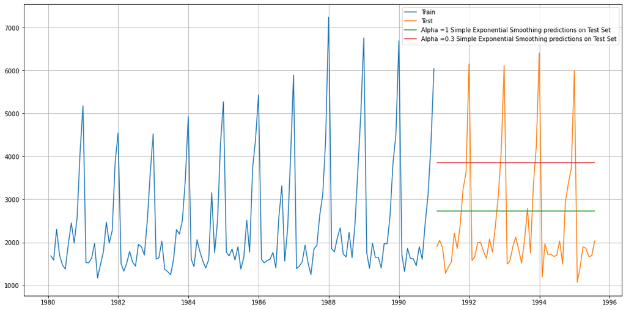

```python
## Plotting on both the Training and Test data

plt.figure(figsize=(18,9))
plt.plot(SES_train['Sparkling'], label='Train')
plt.plot(SES_test['Sparkling'], label='Test')

plt.plot(SES_test['predict'], label='Alpha =1 Simple Exponential Smoothing predictions on Test Set')

plt.plot(SES_test['predict', 0.3], label='Alpha =0.3 Simple Exponential Smoothing predictions on Test Set')



plt.legend(loc='best')
plt.grid();
```

```python
resultsDf_6_1 = pd.DataFrame({'Test RMSE': [resultsDf_6.sort_values(by=['Test RMSE'],ascending=True).values[0][2]]}
                           ,index=['Alpha=0.3,SimpleExponentialSmoothing'])

resultsDf = pd.concat([resultsDf, resultsDf_6_1])
resultsDf
```

|  | Test RMSE |
| --- | --- |
| RegressionOnTime | 1389.135175 |
| NaiveModel | 3864.279352 |
| SimpleAverageModel | 1275.081804 |
| 2pointTrailingMovingAverage | 813.400684 |
| 4pointTrailingMovingAverage | 1156.589694 |
| 6pointTrailingMovingAverage | 1283.927428 |
| 9pointTrailingMovingAverage | 1346.278315 |
| Alpha=0.995,SimpleExponentialSmoothing | 1316.035487 |
| Alpha=0.3,SimpleExponentialSmoothing | 1935.507132 |

### Method 6: Double Exponential Smoothing (Holt's Model)

Two parameters α and β are estimated in this model. Level and Trend are accounted for in this model.

```python
DES_train = train.copy()
DES_test = test.copy()
```

```python
model_DES = Holt(DES_train['Sparkling'])
```

```python
## First we will define an empty dataframe to store our values from the loop

resultsDf_7 = pd.DataFrame({'Alpha Values':[],'Beta Values':[],'Train RMSE':[],'Test RMSE': []})
resultsDf_7
```

|  | Alpha Values | Beta Values | Train RMSE | Test RMSE |
| --- | --- | --- | --- | --- |

```python
for i in np.arange(0.3,1.1,0.1):
    for j in np.arange(0.3,1.1,0.1):
        model_DES_alpha_i_j = model_DES.fit(smoothing_level=i,smoothing_trend=j,optimized=False,use_brute=True)
        DES_train['predict',i,j] = model_DES_alpha_i_j.fittedvalues
        DES_test['predict',i,j] = model_DES_alpha_i_j.forecast(steps=55)

        rmse_model6_train = metrics.mean_squared_error(DES_train['Sparkling'],DES_train['predict',i,j],squared=False)

        rmse_model6_test = metrics.mean_squared_error(DES_test['Sparkling'],DES_test['predict',i,j],squared=False)

        resultsDf_7 = resultsDf_7.append({'Alpha Values':i,'Beta Values':j,'Train RMSE':rmse_model6_train
                                          ,'Test RMSE':rmse_model6_test}, ignore_index=True)
```

```python
resultsDf_7
```

|  | Alpha Values | Beta Values | Train RMSE | Test RMSE |
| --- | --- | --- | --- | --- |
| 0 | 0.3 | 0.3 | 1592.292788 | 18259.110704 |
| 1 | 0.3 | 0.4 | 1682.573828 | 26069.841401 |
| 2 | 0.3 | 0.5 | 1771.710791 | 34401.512440 |
| 3 | 0.3 | 0.6 | 1848.576510 | 42162.748095 |
| 4 | 0.3 | 0.7 | 1899.949006 | 47832.397419 |
| ... | ... | ... | ... | ... |
| 59 | 1.0 | 0.6 | 1753.402326 | 49327.087977 |
| 60 | 1.0 | 0.7 | 1825.187155 | 52655.765663 |
| 61 | 1.0 | 0.8 | 1902.013709 | 55442.273880 |
| 62 | 1.0 | 0.9 | 1985.368445 | 57823.177011 |
| 63 | 1.0 | 1.0 | 2077.672157 | 59877.076519 |

64 rows × 4 columns

```python
resultsDf_7.sort_values(by=['Test RMSE']).head()
```

|  | Alpha Values | Beta Values | Train RMSE | Test RMSE |
| --- | --- | --- | --- | --- |
| 0 | 0.3 | 0.3 | 1592.292788 | 18259.110704 |
| 8 | 0.4 | 0.3 | 1569.338606 | 23878.496940 |
| 1 | 0.3 | 0.4 | 1682.573828 | 26069.841401 |
| 16 | 0.5 | 0.3 | 1530.575845 | 27095.532414 |
| 24 | 0.6 | 0.3 | 1506.449870 | 29070.722592 |

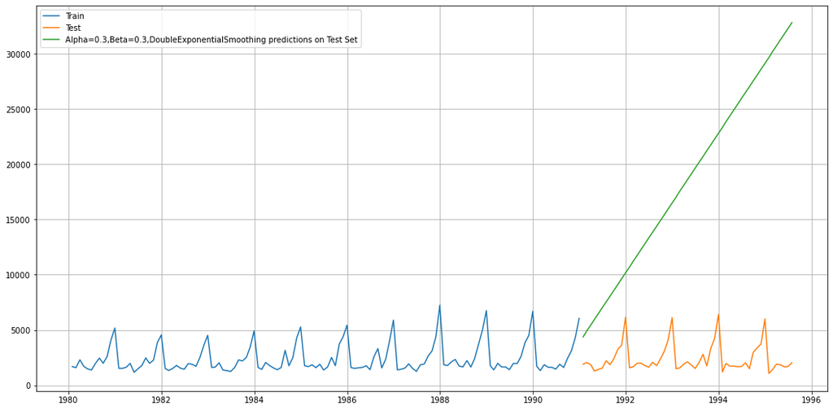

```python
## Plotting on both the Training and Test data

plt.figure(figsize=(18,9))
plt.plot(DES_train['Sparkling'], label='Train')
plt.plot(DES_test['Sparkling'], label='Test')

plt.plot(DES_test['predict', 0.3, 0.3], label='Alpha=0.3,Beta=0.3,DoubleExponentialSmoothing predictions on Test Set')


plt.legend(loc='best')
plt.grid();
```

```python
resultsDf_7_1 = pd.DataFrame({'Test RMSE': [resultsDf_7.sort_values(by=['Test RMSE']).values[0][3]]}
                           ,index=['Alpha=0.3,Beta=0.3,DoubleExponentialSmoothing'])

resultsDf = pd.concat([resultsDf, resultsDf_7_1])
resultsDf
```

|  | Test RMSE |
| --- | --- |
| RegressionOnTime | 1389.135175 |
| NaiveModel | 3864.279352 |
| SimpleAverageModel | 1275.081804 |
| 2pointTrailingMovingAverage | 813.400684 |
| 4pointTrailingMovingAverage | 1156.589694 |
| 6pointTrailingMovingAverage | 1283.927428 |
| 9pointTrailingMovingAverage | 1346.278315 |
| Alpha=0.995,SimpleExponentialSmoothing | 1316.035487 |
| Alpha=0.3,SimpleExponentialSmoothing | 1935.507132 |
| Alpha=0.3,Beta=0.3,DoubleExponentialSmoothing | 18259.110704 |

### Method 7: Triple Exponential Smoothing (Holt - Winter's Model)

Three parameters α, β and γ are estimated in this model. Level, Trend and Seasonality are accounted for in this model.

```python
TES_train = train.copy()
TES_test = test.copy()
```

```python
model_TES = ExponentialSmoothing(TES_train['Sparkling'],trend='additive',seasonal='multiplicative',freq='M')
```

```python
model_TES_autofit = model_TES.fit()
```

The above fit of the model is by the best parameters that Python thinks for the model. It uses a brute force method to choose the parameters.

```python
model_TES_autofit.params
```

```
{'smoothing_level': 0.111108139467838,
 'smoothing_trend': 0.06172875597197263,
 'smoothing_seasonal': 0.3950479631147446,
 'damping_trend': nan,
 'initial_level': 1639.9340657558994,
 'initial_trend': -12.22494561218149,
 'initial_seasons': array([1.06402008, 1.02352078, 1.40671876, 1.20165543, 0.97593   ,
        0.97100155, 1.31897446, 1.69588922, 1.3895294 , 1.81476396,
        2.85150039, 3.62470528]),
 'use_boxcox': False,
 'lamda': None,
 'remove_bias': False}
```

```python
## Prediction on the test data

TES_test['auto_predict'] = model_TES_autofit.forecast(steps=len(test))
TES_test.head()
```

| Time_Stamp | Sparkling | auto_predict |
| --- | --- | --- |
| 1991-01-31 | 1902 | 1577.224489 |
| 1991-02-28 | 2049 | 1333.677558 |
| 1991-03-31 | 1874 | 1745.945679 |
| 1991-04-30 | 1279 | 1630.411925 |
| 1991-05-31 | 1432 | 1523.289070 |

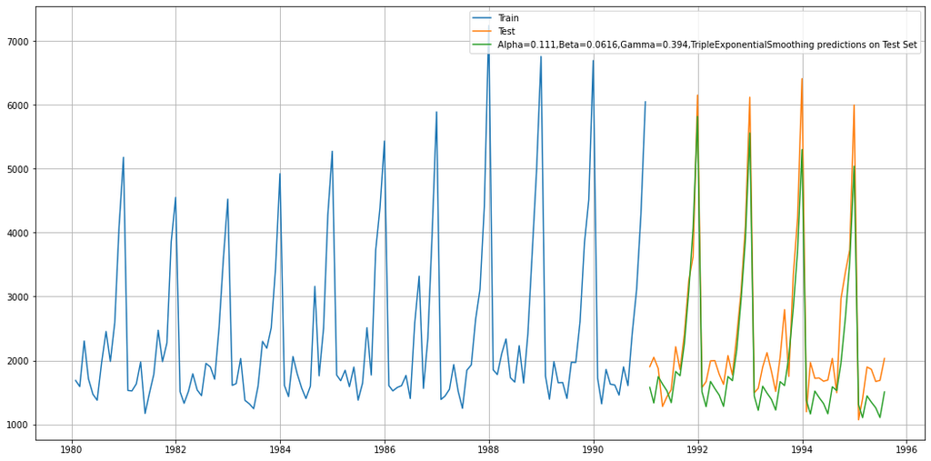

```python
## Plotting on both the Training and Test using autofit

plt.figure(figsize=(18,9))
plt.plot(TES_train['Sparkling'], label='Train')
plt.plot(TES_test['Sparkling'], label='Test')

plt.plot(TES_test['auto_predict'], label='Alpha=0.111,Beta=0.0616,Gamma=0.394,TripleExponentialSmoothing predictions on Test Set')


plt.legend(loc='best')
plt.grid();
```

```python
## Test Data

rmse_model6_test_1 = metrics.mean_squared_error(TES_test['Sparkling'],TES_test['auto_predict'],squared=False)
print("For Alpha=0.111,Beta=0.0616,Gamma=0.394, Triple Exponential Smoothing Model forecast on the Test Data,  RMSE is %3.3f" %(rmse_model6_test_1))
```

```
For Alpha=0.111,Beta=0.0616,Gamma=0.394, Triple Exponential Smoothing Model forecast on the Test Data,  RMSE is 469.768
```

```python
resultsDf_8_1 = pd.DataFrame({'Test RMSE': [rmse_model6_test_1]}
                           ,index=['Alpha=0.111,Beta=0.0616,Gamma=0.394,TripleExponentialSmoothing'])

resultsDf = pd.concat([resultsDf, resultsDf_8_1])
resultsDf
```

|  | Test RMSE |
| --- | --- |
| RegressionOnTime | 1389.135175 |
| NaiveModel | 3864.279352 |
| SimpleAverageModel | 1275.081804 |
| 2pointTrailingMovingAverage | 813.400684 |
| 4pointTrailingMovingAverage | 1156.589694 |
| 6pointTrailingMovingAverage | 1283.927428 |
| 9pointTrailingMovingAverage | 1346.278315 |
| Alpha=0.995,SimpleExponentialSmoothing | 1316.035487 |
| Alpha=0.3,SimpleExponentialSmoothing | 1935.507132 |
| Alpha=0.3,Beta=0.3,DoubleExponentialSmoothing | 18259.110704 |
| Alpha=0.111,Beta=0.0616,Gamma=0.394,TripleExponentialSmoothing | 469.767970 |

```python
## First we will define an empty dataframe to store our values from the loop

resultsDf_8_2 = pd.DataFrame({'Alpha Values':[],'Beta Values':[],'Gamma Values':[],'Train RMSE':[],'Test RMSE': []})
resultsDf_8_2
```

|  | Alpha Values | Beta Values | Gamma Values | Train RMSE | Test RMSE |
| --- | --- | --- | --- | --- | --- |

```python
for i in np.arange(0.3,1.1,0.1):
    for j in np.arange(0.3,1.1,0.1):
        for k in np.arange(0.3,1.1,0.1):
            model_TES_alpha_i_j_k = model_TES.fit(smoothing_level=i,smoothing_trend=j,smoothing_seasonal=k,optimized=False,use_brute=True)
            TES_train['predict',i,j,k] = model_TES_alpha_i_j_k.fittedvalues
            TES_test['predict',i,j,k] = model_TES_alpha_i_j_k.forecast(steps=55)

            rmse_model8_train = metrics.mean_squared_error(TES_train['Sparkling'],TES_train['predict',i,j,k],squared=False)

            rmse_model8_test = metrics.mean_squared_error(TES_test['Sparkling'],TES_test['predict',i,j,k],squared=False)

            resultsDf_8_2 = resultsDf_8_2.append({'Alpha Values':i,'Beta Values':j,'Gamma Values':k,
                                                  'Train RMSE':rmse_model8_train,'Test RMSE':rmse_model8_test}
                                                 , ignore_index=True)
```

```python
resultsDf_8_2
```

|  | Alpha Values | Beta Values | Gamma Values | Train RMSE | Test RMSE |
| --- | --- | --- | --- | --- | --- |
| 0 | 0.3 | 0.3 | 0.3 | 404.513320 | 3.927862e+02 |
| 1 | 0.3 | 0.3 | 0.4 | 402.088628 | 9.513202e+02 |
| 2 | 0.3 | 0.3 | 0.5 | 408.282432 | 1.470487e+03 |
| 3 | 0.3 | 0.3 | 0.6 | 428.631668 | 2.181724e+03 |
| 4 | 0.3 | 0.3 | 0.7 | 468.958530 | 3.513351e+03 |
| ... | ... | ... | ... | ... | ... |
| 507 | 1.0 | 1.0 | 0.6 | 153394.791826 | 7.989790e+05 |
| 508 | 1.0 | 1.0 | 0.7 | 94040.964958 | 1.074413e+06 |
| 509 | 1.0 | 1.0 | 0.8 | 102196.953755 | 5.010607e+06 |
| 510 | 1.0 | 1.0 | 0.9 | 77924.294413 | 4.318265e+05 |
| 511 | 1.0 | 1.0 | 1.0 | 239917.432847 | 1.254280e+05 |

512 rows × 5 columns

```python
resultsDf_8_2.sort_values(by=['Test RMSE']).head()
```

|  | Alpha Values | Beta Values | Gamma Values | Train RMSE | Test RMSE |
| --- | --- | --- | --- | --- | --- |
| 0 | 0.3 | 0.3 | 0.3 | 404.513320 | 392.786198 |
| 8 | 0.3 | 0.4 | 0.3 | 424.828055 | 410.854547 |
| 65 | 0.4 | 0.3 | 0.4 | 435.553595 | 421.409170 |
| 296 | 0.7 | 0.8 | 0.3 | 700.317756 | 518.188752 |
| 130 | 0.5 | 0.3 | 0.5 | 498.239915 | 542.175497 |

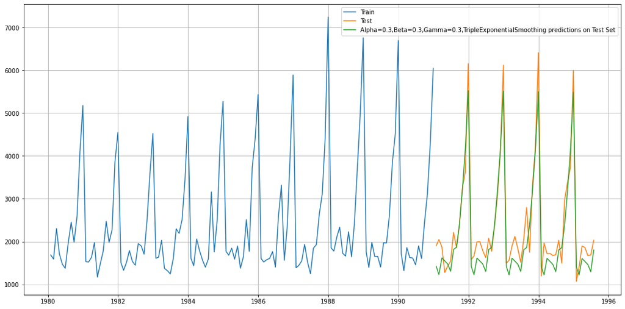

```python
## Plotting on both the Training and Test data using brute force alpha, beta and gamma determination

plt.figure(figsize=(18,9))
plt.plot(TES_train['Sparkling'], label='Train')
plt.plot(TES_test['Sparkling'], label='Test')

#The value of alpha and beta is taken like that by python
plt.plot(TES_test['predict', 0.3, 0.3, 0.3], label='Alpha=0.3,Beta=0.3,Gamma=0.3,TripleExponentialSmoothing predictions on Test Set')


plt.legend(loc='best')
plt.grid();
```

```python
resultsDf_8_3 = pd.DataFrame({'Test RMSE': [resultsDf_8_2.sort_values(by=['Test RMSE']).values[0][4]]}
                           ,index=['Alpha=0.3,Beta=0.3,Gamma=0.3,TripleExponentialSmoothing'])

resultsDf = pd.concat([resultsDf, resultsDf_8_3])
resultsDf
```

|  | Test RMSE |
| --- | --- |
| RegressionOnTime | 1389.135175 |
| NaiveModel | 3864.279352 |
| SimpleAverageModel | 1275.081804 |
| 2pointTrailingMovingAverage | 813.400684 |
| 4pointTrailingMovingAverage | 1156.589694 |
| 6pointTrailingMovingAverage | 1283.927428 |
| 9pointTrailingMovingAverage | 1346.278315 |
| Alpha=0.995,SimpleExponentialSmoothing | 1316.035487 |
| Alpha=0.3,SimpleExponentialSmoothing | 1935.507132 |
| Alpha=0.3,Beta=0.3,DoubleExponentialSmoothing | 18259.110704 |
| Alpha=0.111,Beta=0.0616,Gamma=0.394,TripleExponentialSmoothing | 469.767970 |
| Alpha=0.3,Beta=0.3,Gamma=0.3,TripleExponentialSmoothing | 392.786198 |

```python
print('Sorted by RMSE values on the Test Data:','\n',)
resultsDf.sort_values(by=['Test RMSE'])
```

```
Sorted by RMSE values on the Test Data:
```

|  | Test RMSE |
| --- | --- |
| Alpha=0.3,Beta=0.3,Gamma=0.3,TripleExponentialSmoothing | 392.786198 |
| Alpha=0.111,Beta=0.0616,Gamma=0.394,TripleExponentialSmoothing | 469.767970 |
| 2pointTrailingMovingAverage | 813.400684 |
| 4pointTrailingMovingAverage | 1156.589694 |
| SimpleAverageModel | 1275.081804 |
| 6pointTrailingMovingAverage | 1283.927428 |
| Alpha=0.995,SimpleExponentialSmoothing | 1316.035487 |
| 9pointTrailingMovingAverage | 1346.278315 |
| RegressionOnTime | 1389.135175 |
| Alpha=0.3,SimpleExponentialSmoothing | 1935.507132 |
| NaiveModel | 3864.279352 |
| Alpha=0.3,Beta=0.3,DoubleExponentialSmoothing | 18259.110704 |

For this data, we had both trend and seasonality so by definition Triple Exponential Smoothing is supposed to work better than the Simple Exponential Smoothing as well as the Double Exponential Smoothing. However, since this was a model building exercise we had gone on to build different models on the data and have compared these model with the best RMSE value on the test data.

### We see that the best model is the Triple Exponential Smoothing with multiplicative seasonality with the parameters α= 0.3, β= 0.3 and γ= 0.3.

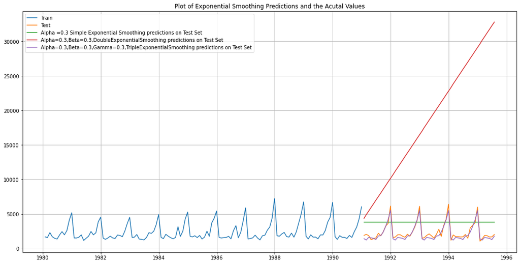

```python
## Plotting on both the Training and Test data

plt.figure(figsize=(18,9))
plt.plot(train['Sparkling'], label='Train')
plt.plot(test['Sparkling'], label='Test')

plt.plot(SES_test['predict', 0.3], label='Alpha =0.3 Simple Exponential Smoothing predictions on Test Set')

plt.plot(DES_test['predict', 0.3, 0.3], label='Alpha=0.3,Beta=0.3,DoubleExponentialSmoothing predictions on Test Set')

plt.plot(TES_test['predict', 0.3, 0.3, 0.3], label='Alpha=0.3,Beta=0.3,Gamma=0.3,TripleExponentialSmoothing predictions on Test Set')

plt.legend(loc='best')
plt.grid();
plt.title('Plot of Exponential Smoothing Predictions and the Acutal Values');
```

### 5. Check for the stationarity of the data on which the model is being built on using appropriate statistical tests and also mention the hypothesis for the statistical test. If the data is found to be non-stationary, take appropriate steps to make it stationary. Check the new data for stationarity and comment.

Note: Stationarity should be checked at alpha = 0.05.

### Check for stationarity of the whole Time Series data.

```python
## Test for stationarity of the series - Dicky Fuller test

from statsmodels.tsa.stattools import adfuller
def test_stationarity(timeseries):

    #Determing rolling statistics
    rolmean = timeseries.rolling(window=7).mean() #determining the rolling mean
    rolstd = timeseries.rolling(window=7).std()   #determining the rolling standard deviation

    #Plot rolling statistics:
    orig = plt.plot(timeseries, color='blue',label='Original')
    mean = plt.plot(rolmean, color='red', label='Rolling Mean')
    std = plt.plot(rolstd, color='black', label = 'Rolling Std')
    plt.legend(loc='best')
    plt.title('Rolling Mean & Standard Deviation')
    plt.show(block=False)

    #Perform Dickey-Fuller test:
    print ('Results of Dickey-Fuller Test:')
    dftest = adfuller(timeseries, autolag='AIC')
    dfoutput = pd.Series(dftest[0:4], index=['Test Statistic','p-value','#Lags Used','Number of Observations Used'])
    for key,value in dftest[4].items():
        dfoutput['Critical Value (%s)'%key] = value
    print (dfoutput,'\n')
```

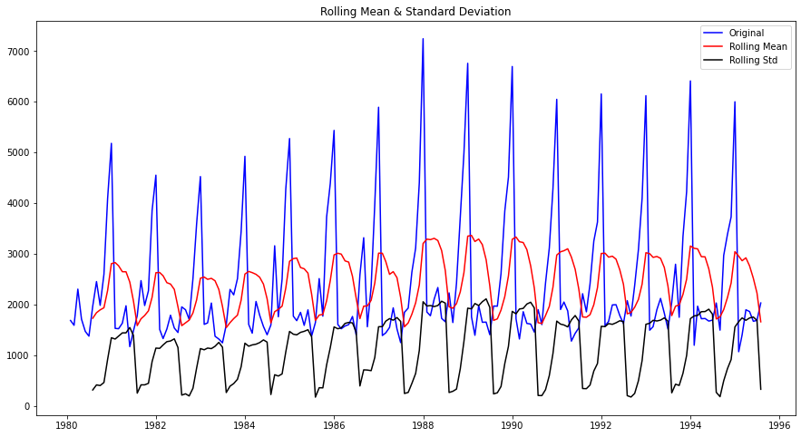

```
Results of Dickey-Fuller Test:
Test Statistic                  -1.360497
p-value                          0.601061
#Lags Used                      11.000000
Number of Observations Used    175.000000
Critical Value (1%)             -3.468280
Critical Value (5%)             -2.878202
Critical Value (10%)            -2.575653
dtype: float64
```

```python
plt.figure(figsize=(15,8))
test_stationarity(df['Sparkling'])
```

We see that at 5% significant level the Time Series is non-stationary.

Let us take a difference of order 1 and check whether the Time Series is stationary or not.

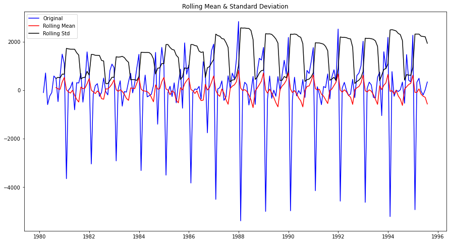

```
Results of Dickey-Fuller Test:
Test Statistic                 -45.050301
p-value                          0.000000
#Lags Used                      10.000000
Number of Observations Used    175.000000
Critical Value (1%)             -3.468280
Critical Value (5%)             -2.878202
Critical Value (10%)            -2.575653
dtype: float64
```

```python
plt.figure(figsize=(15,8))
test_stationarity(df['Sparkling'].diff().dropna())
```

We see that at α= 0.05 the Time Series is indeed stationary

### 6. Build an automated version of the ARIMA/SARIMA model in which the parameters are selected using the lowest Akaike Information Criteria (AIC) on the training data and evaluate this model on the test data using RMSE.

```python
## The following loop helps us in getting a combination of different parameters of p and q in the range of 0 and 2
## We have kept the value of d as 1 as we need to take a difference of the series to make it stationary.

import itertools
p = q = range(0, 3)
d= range(1,2)
pdq = list(itertools.product(p, d, q))
print('Some parameter combinations for the Model...')
for i in range(1,len(pdq)):
    print('Model: {}'.format(pdq[i]))
```

```
Some parameter combinations for the Model...
Model: (0, 1, 1)
Model: (0, 1, 2)
Model: (1, 1, 0)
Model: (1, 1, 1)
Model: (1, 1, 2)
Model: (2, 1, 0)
Model: (2, 1, 1)
Model: (2, 1, 2)
```

```python
# Creating an empty Dataframe with column names only
ARIMA_AIC = pd.DataFrame(columns=['param', 'AIC'])
ARIMA_AIC
```

|  | param | AIC |
| --- | --- | --- |

```python
from statsmodels.tsa.arima_model import ARIMA

for param in pdq:
    ARIMA_model = ARIMA(train['Sparkling'].values,order=param).fit()
    print('ARIMA{} - AIC:{}'.format(param,ARIMA_model.aic))
    ARIMA_AIC = ARIMA_AIC.append({'param':param, 'AIC': ARIMA_model.aic}, ignore_index=True)
```

```
ARIMA(0, 1, 0) - AIC:2269.582796371201
```

```
ARIMA(0, 1, 1) - AIC:2264.906438611577
ARIMA(0, 1, 2) - AIC:2232.78309768405
ARIMA(1, 1, 0) - AIC:2268.5280607650034
```

```
ARIMA(1, 1, 1) - AIC:2235.0139453493175
```

```
ARIMA(1, 1, 2) - AIC:2233.597647121205
ARIMA(2, 1, 0) - AIC:2262.035600155025
```

```
ARIMA(2, 1, 1) - AIC:2232.3604899121387
ARIMA(2, 1, 2) - AIC:2210.6260491378257
```

```python
## Sort the above AIC values in the ascending order to get the parameters for the minimum AIC value

ARIMA_AIC.sort_values(by='AIC',ascending=True)
```

|  | param | AIC |
| --- | --- | --- |
| 8 | (2, 1, 2) | 2210.626049 |
| 7 | (2, 1, 1) | 2232.360490 |
| 2 | (0, 1, 2) | 2232.783098 |
| 5 | (1, 1, 2) | 2233.597647 |
| 4 | (1, 1, 1) | 2235.013945 |
| 6 | (2, 1, 0) | 2262.035600 |
| 1 | (0, 1, 1) | 2264.906439 |
| 3 | (1, 1, 0) | 2268.528061 |
| 0 | (0, 1, 0) | 2269.582796 |

```python
auto_ARIMA = ARIMA(train['Sparkling'], order=(2,1,2),freq='M')

results_auto_ARIMA = auto_ARIMA.fit()

print(results_auto_ARIMA.summary())
```

```
                             ARIMA Model Results
==============================================================================
Dep. Variable:            D.Sparkling   No. Observations:                  131
Model:                 ARIMA(2, 1, 2)   Log Likelihood               -1099.313
Method:                       css-mle   S.D. of innovations           1013.755
Date:                Sat, 25 Dec 2021   AIC                           2210.626
Time:                        22:19:17   BIC                           2227.877
Sample:                    02-29-1980   HQIC                          2217.636
                         - 12-31-1990
=====================================================================================
                        coef    std err          z      P>|z|      [0.025      0.975]
-------------------------------------------------------------------------------------
const                 5.5845      0.519     10.753      0.000       4.567       6.602
ar.L1.D.Sparkling     1.2698      0.075     17.040      0.000       1.124       1.416
ar.L2.D.Sparkling    -0.5601      0.074     -7.617      0.000      -0.704      -0.416
ma.L1.D.Sparkling    -1.9957      0.043    -46.821      0.000      -2.079      -1.912
ma.L2.D.Sparkling     0.9957      0.043     23.291      0.000       0.912       1.079
                                    Roots
=============================================================================
                  Real          Imaginary           Modulus         Frequency
-----------------------------------------------------------------------------
AR.1            1.1335           -0.7074j            1.3361           -0.0888
AR.2            1.1335           +0.7074j            1.3361            0.0888
MA.1            1.0000           +0.0000j            1.0000            0.0000
MA.2            1.0043           +0.0000j            1.0043            0.0000
-----------------------------------------------------------------------------
```

```python
final_hat_avg =test.copy()
pred_ARIMA = results_auto_ARIMA.forecast(steps=len(test))
pred_ARIMA[0]
```

```
array([4249.61500226, 2821.04020791, 2015.39465985, 1794.18417138,
       1966.18292558, 2310.12631279, 2652.15739561, 2895.44576479,
       3014.4174219 , 3030.83669508, 2986.66611064, 2923.00031134,
       2868.51788927, 2836.61712667, 2828.24751127, 2837.10972827,
       2854.6727745 , 2873.6321496 , 2889.49089597, 2900.63017586,
       2907.51327747, 2911.63529292, 2914.63524682, 2917.75697307,
       2921.66185142, 2926.49300059, 2932.06168881, 2938.04808842,
       2944.15178575, 2950.17045287, 2956.01544082, 2961.6875127 ,
       2967.23729407, 2972.72864403, 2978.21429596, 2983.72544246,
       2989.27215488, 2994.84974972, 3000.44663829, 3006.05072816,
       3011.65315524, 3017.24943704, 3022.83884669, 3028.42297205,
       3034.0042366 , 3039.58482835, 3045.16616823, 3050.74883497,
       3056.33276757, 3061.91756437, 3067.5027495 , 3073.08794367,
       3078.6729318 , 3084.25765323, 3089.84215139])
```

### Predict on the Test Set using this model and evaluate the model.

```python
predicted_auto_ARIMA = results_auto_ARIMA.forecast(steps=len(test))
```

```python
from sklearn.metrics import  mean_squared_error
rmse = mean_squared_error(test['Sparkling'],predicted_auto_ARIMA[0],squared=False)
print(rmse)
```

```
1374.0370092580251
```

```python
resultsDf_9 = pd.DataFrame({'RMSE': [rmse]}
                           ,index=['ARIMA(2,1,2)'])

resultsDf = pd.concat([resultsDf, resultsDf_9])
resultsDf
```

|  | Test RMSE | RMSE |
| --- | --- | --- |
| RegressionOnTime | 1389.135175 | NaN |
| NaiveModel | 3864.279352 | NaN |
| SimpleAverageModel | 1275.081804 | NaN |
| 2pointTrailingMovingAverage | 813.400684 | NaN |
| 4pointTrailingMovingAverage | 1156.589694 | NaN |
| 6pointTrailingMovingAverage | 1283.927428 | NaN |
| 9pointTrailingMovingAverage | 1346.278315 | NaN |
| Alpha=0.995,SimpleExponentialSmoothing | 1316.035487 | NaN |
| Alpha=0.3,SimpleExponentialSmoothing | 1935.507132 | NaN |
| Alpha=0.3,Beta=0.3,DoubleExponentialSmoothing | 18259.110704 | NaN |
| Alpha=0.111,Beta=0.0616,Gamma=0.394,TripleExponentialSmoothing | 469.767970 | NaN |
| Alpha=0.3,Beta=0.3,Gamma=0.3,TripleExponentialSmoothing | 392.786198 | NaN |
| ARIMA(2,1,2) | NaN | 1374.037009 |

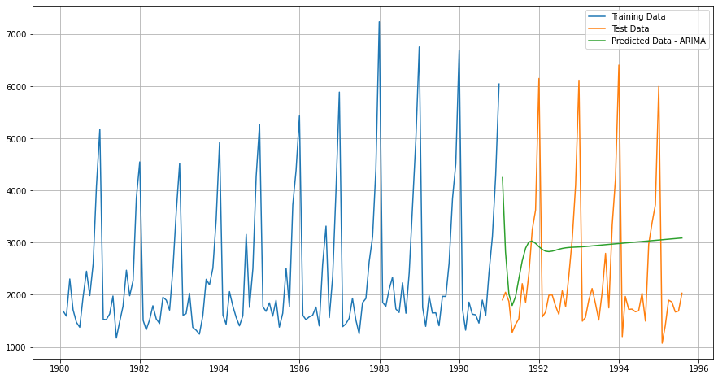

```python
plt.figure(figsize=(15,8))
plt.plot(train,label='Training Data')
plt.plot(test,label='Test Data')
plt.plot(test.index,pred_ARIMA[0],label='Predicted Data - ARIMA')
plt.legend(loc='best')
plt.grid();
```

### Build an SARIMA model.

```python
from statsmodels.graphics.tsaplots import plot_acf, plot_pacf
```

```python
plot_acf(train.diff(),title='Training Data Autocorrelation',missing='drop');
```

[output not shown]

```python
import itertools
p = q = range(0, 4)
d= range(1,2)
D = range(0,1)
pdq = list(itertools.product(p, d, q))
PDQ = [(x[0], x[1], x[2], 6) for x in list(itertools.product(p, D, q))]
print('Examples of the parameter combinations for the Model are')
for i in range(1,len(pdq)):
    print('Model: {}{}'.format(pdq[i], PDQ[i]))
```

```
Examples of the parameter combinations for the Model are
Model: (0, 1, 1)(0, 0, 1, 6)
Model: (0, 1, 2)(0, 0, 2, 6)
Model: (0, 1, 3)(0, 0, 3, 6)
Model: (1, 1, 0)(1, 0, 0, 6)
Model: (1, 1, 1)(1, 0, 1, 6)
Model: (1, 1, 2)(1, 0, 2, 6)
Model: (1, 1, 3)(1, 0, 3, 6)
Model: (2, 1, 0)(2, 0, 0, 6)
Model: (2, 1, 1)(2, 0, 1, 6)
Model: (2, 1, 2)(2, 0, 2, 6)
Model: (2, 1, 3)(2, 0, 3, 6)
Model: (3, 1, 0)(3, 0, 0, 6)
Model: (3, 1, 1)(3, 0, 1, 6)
Model: (3, 1, 2)(3, 0, 2, 6)
Model: (3, 1, 3)(3, 0, 3, 6)
```

```python
### As the dataset has seasonality.. Let's build the model with SARIMA
SARIMA_AIC = pd.DataFrame(columns=['param','seasonal', 'AIC'])
SARIMA_AIC
```

|  | param | seasonal | AIC |
| --- | --- | --- | --- |

```python
import statsmodels.api as sm

for param in pdq:
    for param_seasonal in PDQ:
        SARIMA_model = sm.tsa.statespace.SARIMAX(train['Sparkling'].values,
                                            order=param,
                                            seasonal_order=param_seasonal,
                                            enforce_stationarity=False,
                                            enforce_invertibility=False)

        results_SARIMA = SARIMA_model.fit(maxiter=1000)
        print('SARIMA{}x{} - AIC:{}'.format(param, param_seasonal, results_SARIMA.aic))
        SARIMA_AIC = SARIMA_AIC.append({'param':param,'seasonal':param_seasonal ,'AIC': results_SARIMA.aic}, ignore_index=True)
```

```
SARIMA(0, 1, 0)x(0, 0, 0, 6) - AIC:2251.3597196862966
SARIMA(0, 1, 0)x(0, 0, 1, 6) - AIC:2152.37807617163
SARIMA(0, 1, 0)x(0, 0, 2, 6) - AIC:1955.6355536892695
SARIMA(0, 1, 0)x(0, 0, 3, 6) - AIC:1863.7845154974284
SARIMA(0, 1, 0)x(1, 0, 0, 6) - AIC:2164.4097581959904
SARIMA(0, 1, 0)x(1, 0, 1, 6) - AIC:2079.5599844430967
SARIMA(0, 1, 0)x(1, 0, 2, 6) - AIC:1926.9360123151866
SARIMA(0, 1, 0)x(1, 0, 3, 6) - AIC:1803.392909511414
```

```
SARIMA(0, 1, 0)x(2, 0, 0, 6) - AIC:1839.4012986872267
SARIMA(0, 1, 0)x(2, 0, 1, 6) - AIC:1841.1993617510475
SARIMA(0, 1, 0)x(2, 0, 2, 6) - AIC:1810.9177805657137
SARIMA(0, 1, 0)x(2, 0, 3, 6) - AIC:1725.5376425548839
SARIMA(0, 1, 0)x(3, 0, 0, 6) - AIC:1748.7622668155268
SARIMA(0, 1, 0)x(3, 0, 1, 6) - AIC:1750.687995381667
SARIMA(0, 1, 0)x(3, 0, 2, 6) - AIC:1739.4489858030697
SARIMA(0, 1, 0)x(3, 0, 3, 6) - AIC:1725.013875788447
SARIMA(0, 1, 1)x(0, 0, 0, 6) - AIC:2230.1629078505853
SARIMA(0, 1, 1)x(0, 0, 1, 6) - AIC:2130.5652859082834
SARIMA(0, 1, 1)x(0, 0, 2, 6) - AIC:1918.1876339538774
SARIMA(0, 1, 1)x(0, 0, 3, 6) - AIC:1826.5285284709955
SARIMA(0, 1, 1)x(1, 0, 0, 6) - AIC:2139.573242878457
SARIMA(0, 1, 1)x(1, 0, 1, 6) - AIC:2006.5174298136812
SARIMA(0, 1, 1)x(1, 0, 2, 6) - AIC:1855.7093274198203
SARIMA(0, 1, 1)x(1, 0, 3, 6) - AIC:1737.6243230916161
SARIMA(0, 1, 1)x(2, 0, 0, 6) - AIC:1798.788510384362
SARIMA(0, 1, 1)x(2, 0, 1, 6) - AIC:1800.7717933054773
SARIMA(0, 1, 1)x(2, 0, 2, 6) - AIC:1741.641477350578
SARIMA(0, 1, 1)x(2, 0, 3, 6) - AIC:1659.2934093253732
SARIMA(0, 1, 1)x(3, 0, 0, 6) - AIC:1708.1153979384214
SARIMA(0, 1, 1)x(3, 0, 1, 6) - AIC:1709.0017319344256
SARIMA(0, 1, 1)x(3, 0, 2, 6) - AIC:1687.1427493356985
SARIMA(0, 1, 1)x(3, 0, 3, 6) - AIC:1661.211888593519
SARIMA(0, 1, 2)x(0, 0, 0, 6) - AIC:2187.4410101687017
SARIMA(0, 1, 2)x(0, 0, 1, 6) - AIC:2087.684384021574
SARIMA(0, 1, 2)x(0, 0, 2, 6) - AIC:1886.1151465001797
SARIMA(0, 1, 2)x(0, 0, 3, 6) - AIC:1794.4778967488185
SARIMA(0, 1, 2)x(1, 0, 0, 6) - AIC:2129.7395689235723
SARIMA(0, 1, 2)x(1, 0, 1, 6) - AIC:1988.4215579818888
SARIMA(0, 1, 2)x(1, 0, 2, 6) - AIC:1839.696321784538
SARIMA(0, 1, 2)x(1, 0, 3, 6) - AIC:1720.5694205920497
SARIMA(0, 1, 2)x(2, 0, 0, 6) - AIC:1791.6537079049822
SARIMA(0, 1, 2)x(2, 0, 1, 6) - AIC:1793.6190987008567
SARIMA(0, 1, 2)x(2, 0, 2, 6) - AIC:1727.8888190129267
SARIMA(0, 1, 2)x(2, 0, 3, 6) - AIC:1646.4155397088514
SARIMA(0, 1, 2)x(3, 0, 0, 6) - AIC:1701.6718648288154
SARIMA(0, 1, 2)x(3, 0, 1, 6) - AIC:1703.5807738801
SARIMA(0, 1, 2)x(3, 0, 2, 6) - AIC:1688.325091965826
SARIMA(0, 1, 2)x(3, 0, 3, 6) - AIC:1648.4140647978109
```

[output cut: 193 more lines]

```
SARIMA(3, 1, 3)x(0, 0, 1, 6) - AIC:2053.1966245731637
SARIMA(3, 1, 3)x(0, 0, 2, 6) - AIC:1912.6738893319507
SARIMA(3, 1, 3)x(0, 0, 3, 6) - AIC:1777.839836044189
SARIMA(3, 1, 3)x(1, 0, 0, 6) - AIC:2068.7187606459806
SARIMA(3, 1, 3)x(1, 0, 1, 6) - AIC:1878.5920430035865
SARIMA(3, 1, 3)x(1, 0, 2, 6) - AIC:1813.4875018817704
SARIMA(3, 1, 3)x(1, 0, 3, 6) - AIC:1695.066664961592
SARIMA(3, 1, 3)x(2, 0, 0, 6) - AIC:1743.3184472684243
SARIMA(3, 1, 3)x(2, 0, 1, 6) - AIC:1745.063298442328
SARIMA(3, 1, 3)x(2, 0, 2, 6) - AIC:1713.15163340866
SARIMA(3, 1, 3)x(2, 0, 3, 6) - AIC:1631.0051029864853
SARIMA(3, 1, 3)x(3, 0, 0, 6) - AIC:1661.1197391736227
SARIMA(3, 1, 3)x(3, 0, 1, 6) - AIC:1663.635658844291
SARIMA(3, 1, 3)x(3, 0, 2, 6) - AIC:1644.5677487858775
SARIMA(3, 1, 3)x(3, 0, 3, 6) - AIC:1640.0047020148925
```

```python
SARIMA_AIC.sort_values(by=['AIC']).head()
```

|  | param | seasonal | AIC |
| --- | --- | --- | --- |
| 187 | (2, 1, 3) | (2, 0, 3, 6) | 1629.051933 |
| 251 | (3, 1, 3) | (2, 0, 3, 6) | 1631.005103 |
| 191 | (2, 1, 3) | (3, 0, 3, 6) | 1631.011332 |
| 59 | (0, 1, 3) | (2, 0, 3, 6) | 1633.327870 |
| 123 | (1, 1, 3) | (2, 0, 3, 6) | 1633.964843 |

```python
import statsmodels.api as sm

auto_SARIMA = sm.tsa.statespace.SARIMAX(train['Sparkling'],
                                order=(2, 1, 3),
                                seasonal_order=(2, 0, 3, 6),
                                enforce_stationarity=False,
                                enforce_invertibility=False)
results_auto_SARIMA = auto_SARIMA.fit(maxiter=1000)
print(results_auto_SARIMA.summary())
```

```
                                     SARIMAX Results
=========================================================================================
Dep. Variable:                         Sparkling   No. Observations:                  132
Model:             SARIMAX(2, 1, 3)x(2, 0, 3, 6)   Log Likelihood                -803.526
Date:                           Sat, 25 Dec 2021   AIC                           1629.052
Time:                                   22:29:29   BIC                           1658.657
Sample:                               01-31-1980   HQIC                          1641.058
                                    - 12-31-1990
Covariance Type:                             opg
==============================================================================
                 coef    std err          z      P>|z|      [0.025      0.975]
------------------------------------------------------------------------------
ar.L1         -1.7439      0.064    -27.170      0.000      -1.870      -1.618
ar.L2         -0.7864      0.069    -11.434      0.000      -0.921      -0.652
ma.L1          1.0831      0.290      3.739      0.000       0.515       1.651
ma.L2         -0.7535      0.123     -6.147      0.000      -0.994      -0.513
ma.L3         -0.8889      0.256     -3.476      0.001      -1.390      -0.388
ar.S.L6       -0.0116      0.029     -0.396      0.692      -0.069       0.046
ar.S.L12       1.0383      0.022     47.312      0.000       0.995       1.081
ma.S.L6        0.3712      0.258      1.438      0.150      -0.135       0.877
ma.S.L12      -0.7561      0.198     -3.818      0.000      -1.144      -0.368
ma.S.L18       0.1122      0.157      0.716      0.474      -0.195       0.419
sigma2      1.034e+05    4.9e-06   2.11e+10      0.000    1.03e+05    1.03e+05
===================================================================================
Ljung-Box (L1) (Q):                   0.01   Jarque-Bera (JB):                14.99
Prob(Q):                              0.93   Prob(JB):                         0.00
Heteroskedasticity (H):               1.50   Skew:                             0.38
Prob(H) (two-sided):                  0.23   Kurtosis:                         4.65
===================================================================================

Warnings:
[1] Covariance matrix calculated using the outer product of gradients (complex-step).
[2] Covariance matrix is singular or near-singular, with condition number 3.96e+26. Standard errors may be unstable.
```

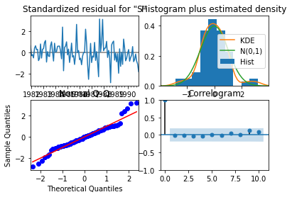

```python
plt.figure(figsize=(20,8))
results_auto_SARIMA.plot_diagnostics();
```

#### Predict on the Test Set using this model and evaluate the model.

```python
predicted_auto_SARIMA = results_auto_SARIMA.get_forecast(steps=len(test))
```

```python
predicted_auto_SARIMA.summary_frame(alpha=0.05).head()
```

| Sparkling | mean | mean_se | mean_ci_lower | mean_ci_upper |
| --- | --- | --- | --- | --- |
| 1991-01-31 | 1343.361652 | 366.413887 | 625.203630 | 2061.519674 |
| 1991-02-28 | 989.021369 | 384.813058 | 234.801634 | 1743.241104 |
| 1991-03-31 | 1647.595998 | 385.052442 | 892.907079 | 2402.284917 |
| 1991-04-30 | 1571.569220 | 395.744508 | 795.924237 | 2347.214203 |
| 1991-05-31 | 1169.188607 | 395.910142 | 393.218987 | 1945.158227 |

```python
rmse = mean_squared_error(test['Sparkling'],predicted_auto_SARIMA.predicted_mean,squared=False)

print('RMSE:',rmse)
```

```
RMSE: 825.6797658268791
```

```python
resultsDf_11 = pd.DataFrame({'Test RMSE': [rmse]},index=['SARIMA(2,1,3)(2,0,3,6)'])


resultsDf = pd.concat([resultsDf,resultsDf_11])

resultsDf
```

|  | Test RMSE | RMSE |
| --- | --- | --- |
| RegressionOnTime | 1389.135175 | NaN |
| NaiveModel | 3864.279352 | NaN |
| SimpleAverageModel | 1275.081804 | NaN |
| 2pointTrailingMovingAverage | 813.400684 | NaN |
| 4pointTrailingMovingAverage | 1156.589694 | NaN |
| 6pointTrailingMovingAverage | 1283.927428 | NaN |
| 9pointTrailingMovingAverage | 1346.278315 | NaN |
| Alpha=0.995,SimpleExponentialSmoothing | 1316.035487 | NaN |
| Alpha=0.3,SimpleExponentialSmoothing | 1935.507132 | NaN |
| Alpha=0.3,Beta=0.3,DoubleExponentialSmoothing | 18259.110704 | NaN |
| Alpha=0.111,Beta=0.0616,Gamma=0.394,TripleExponentialSmoothing | 469.767970 | NaN |
| Alpha=0.3,Beta=0.3,Gamma=0.3,TripleExponentialSmoothing | 392.786198 | NaN |
| ARIMA(2,1,2) | NaN | 1374.037009 |
| SARIMA(2,1,3)(2,0,3,6) | 825.679766 | NaN |

### 7. Build ARIMA/SARIMA models based on the cut-off points of ACF and PACF on the training data and evaluate this model on the test data using RMSE.

```python
from statsmodels.graphics.tsaplots import plot_acf, plot_pacf
```

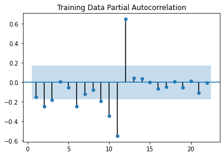

```python
plt.figure(figsize=(15,8))
plot_acf(train.diff(),title='Training Data Autocorrelation',missing='drop')
plot_pacf(train.diff().dropna(),title='Training Data Partial Autocorrelation',zero=False,method='ywmle')
plt.show()
```

[output not shown]

Here, we have taken alpha=0.05.

```python
manual_ARIMA = ARIMA(train['Sparkling'], order=(3,1,3),freq='M')

results_manual_ARIMA = manual_ARIMA.fit()

print(results_manual_ARIMA.summary())
```

```
                             ARIMA Model Results
==============================================================================
Dep. Variable:            D.Sparkling   No. Observations:                  131
Model:                 ARIMA(3, 1, 3)   Log Likelihood               -1104.831
Method:                       css-mle   S.D. of innovations           1074.561
Date:                Sat, 25 Dec 2021   AIC                           2225.662
Time:                        23:34:47   BIC                           2248.663
Sample:                    02-29-1980   HQIC                          2235.008
                         - 12-31-1990
=====================================================================================
                        coef    std err          z      P>|z|      [0.025      0.975]
-------------------------------------------------------------------------------------
const                 6.3212      4.207      1.503      0.133      -1.924      14.566
ar.L1.D.Sparkling    -0.7550      0.093     -8.099      0.000      -0.938      -0.572
ar.L2.D.Sparkling    -0.3887      0.110     -3.533      0.000      -0.604      -0.173
ar.L3.D.Sparkling     0.2143      0.089      2.395      0.017       0.039       0.390
ma.L1.D.Sparkling     0.3401      0.006     55.867      0.000       0.328       0.352
ma.L2.D.Sparkling    -0.3401      0.037     -9.308      0.000      -0.412      -0.268
ma.L3.D.Sparkling    -1.0000        nan        nan        nan         nan         nan
                                    Roots
=============================================================================
                  Real          Imaginary           Modulus         Frequency
-----------------------------------------------------------------------------
AR.1           -0.7463           -0.9244j            1.1880           -0.3581
AR.2           -0.7463           +0.9244j            1.1880            0.3581
AR.3            3.3064           -0.0000j            3.3064           -0.0000
MA.1            1.0000           -0.0000j            1.0000           -0.0000
MA.2           -0.6700           -0.7423j            1.0000           -0.3669
MA.3           -0.6700           +0.7423j            1.0000            0.3669
-----------------------------------------------------------------------------
```

```python
predicted_manual_ARIMA = results_manual_ARIMA.forecast(steps=len(test))
```

```python
rmse = mean_squared_error(test['Sparkling'],predicted_manual_ARIMA[0],squared=False)
print(rmse)
```

```
1425.0933338008322
```

```python
resultsDf_12 = pd.DataFrame({'RMSE': [rmse]}
                           ,index=['ARIMA(3,1,3)'])


resultsDf = pd.concat([resultsDf,resultsDf_12])

resultsDf
```

|  | Test RMSE | RMSE |
| --- | --- | --- |
| RegressionOnTime | 1389.135175 | NaN |
| NaiveModel | 3864.279352 | NaN |
| SimpleAverageModel | 1275.081804 | NaN |
| 2pointTrailingMovingAverage | 813.400684 | NaN |
| 4pointTrailingMovingAverage | 1156.589694 | NaN |
| 6pointTrailingMovingAverage | 1283.927428 | NaN |
| 9pointTrailingMovingAverage | 1346.278315 | NaN |
| Alpha=0.995,SimpleExponentialSmoothing | 1316.035487 | NaN |
| Alpha=0.3,SimpleExponentialSmoothing | 1935.507132 | NaN |
| Alpha=0.3,Beta=0.3,DoubleExponentialSmoothing | 18259.110704 | NaN |
| Alpha=0.111,Beta=0.0616,Gamma=0.394,TripleExponentialSmoothing | 469.767970 | NaN |
| Alpha=0.3,Beta=0.3,Gamma=0.3,TripleExponentialSmoothing | 392.786198 | NaN |
| ARIMA(2,1,2) | NaN | 1374.037009 |
| SARIMA(2,1,3)(2,0,3,6) | 825.679766 | NaN |
| ARIMA(3,1,3) | NaN | 1425.093334 |

#### Predict on the Test Set using this model and evaluate the model.

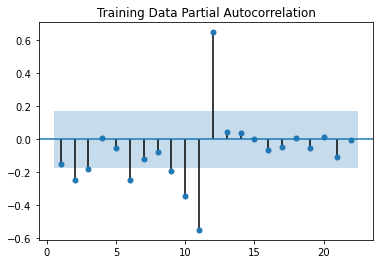

```python
plot_acf(train.diff(),title='Training Data Autocorrelation',missing='drop')
plot_pacf(train.diff().dropna(),title='Training Data Partial Autocorrelation',zero=False,method='ywmle');
```

[output not shown]

```python
import statsmodels.api as sm

manual_SARIMA = sm.tsa.statespace.SARIMAX(train['Sparkling'],
                                order=(3,1,3),
                                seasonal_order=(0, 0, 0, 6),
                                enforce_stationarity=False,
                                enforce_invertibility=False)
results_manual_SARIMA = manual_SARIMA.fit(maxiter=1000)
print(results_manual_SARIMA.summary())
```

```
                               SARIMAX Results
==============================================================================
Dep. Variable:              Sparkling   No. Observations:                  132
Model:               SARIMAX(3, 1, 3)   Log Likelihood               -1070.887
Date:                Sat, 25 Dec 2021   AIC                           2155.775
Time:                        23:35:08   BIC                           2175.684
Sample:                    01-31-1980   HQIC                          2163.864
                         - 12-31-1990
Covariance Type:                  opg
==============================================================================
                 coef    std err          z      P>|z|      [0.025      0.975]
------------------------------------------------------------------------------
ar.L1          0.3554      0.140      2.537      0.011       0.081       0.630
ar.L2         -0.9352      0.062    -14.998      0.000      -1.057      -0.813
ar.L3          0.3664      0.123      2.972      0.003       0.125       0.608
ma.L1         -0.7979      0.100     -8.002      0.000      -0.993      -0.602
ma.L2          0.7965      0.146      5.442      0.000       0.510       1.083
ma.L3         -0.9642      0.144     -6.710      0.000      -1.246      -0.683
sigma2      1.519e+06   3.13e+05      4.860      0.000    9.07e+05    2.13e+06
===================================================================================
Ljung-Box (L1) (Q):                   0.05   Jarque-Bera (JB):                 5.68
Prob(Q):                              0.82   Prob(JB):                         0.06
Heteroskedasticity (H):               2.87   Skew:                             0.47
Prob(H) (two-sided):                  0.00   Kurtosis:                         3.44
===================================================================================

Warnings:
[1] Covariance matrix calculated using the outer product of gradients (complex-step).
```

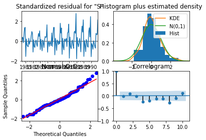

```python
results_manual_SARIMA.plot_diagnostics()
plt.show()
```

#### Predict on the Test Set using this model and evaluate the model.

```python
predicted_manual_SARIMA = results_manual_SARIMA.get_forecast(steps=len(test))
```

```python
rmse = mean_squared_error(test['Sparkling'],predicted_manual_SARIMA.predicted_mean,squared=False)

print('RMSE:',rmse)
```

```
RMSE: 1286.6524091711076
```

### 8. Build a table with all the models built along with their corresponding parameters and the respective RMSE values on the test data.

```python
resultsDf_13 = pd.DataFrame({'Test RMSE': [rmse]}
                           ,index=['SARIMA(3,1,3)(0,0,0,6)'])


resultsDf = pd.concat([resultsDf,resultsDf_13])

resultsDf
```

|  | Test RMSE | RMSE |
| --- | --- | --- |
| RegressionOnTime | 1389.135175 | NaN |
| NaiveModel | 3864.279352 | NaN |
| SimpleAverageModel | 1275.081804 | NaN |
| 2pointTrailingMovingAverage | 813.400684 | NaN |
| 4pointTrailingMovingAverage | 1156.589694 | NaN |
| 6pointTrailingMovingAverage | 1283.927428 | NaN |
| 9pointTrailingMovingAverage | 1346.278315 | NaN |
| Alpha=0.995,SimpleExponentialSmoothing | 1316.035487 | NaN |
| Alpha=0.3,SimpleExponentialSmoothing | 1935.507132 | NaN |
| Alpha=0.3,Beta=0.3,DoubleExponentialSmoothing | 18259.110704 | NaN |
| Alpha=0.111,Beta=0.0616,Gamma=0.394,TripleExponentialSmoothing | 469.767970 | NaN |
| Alpha=0.3,Beta=0.3,Gamma=0.3,TripleExponentialSmoothing | 392.786198 | NaN |
| ARIMA(2,1,2) | NaN | 1374.037009 |
| SARIMA(2,1,3)(2,0,3,6) | 825.679766 | NaN |
| ARIMA(3,1,3) | NaN | 1425.093334 |
| SARIMA(3,1,3)(0,0,0,6) | 1286.652409 | NaN |

### 9. Based on the model-building exercise, build the most optimum model(s) on the complete data and predict 12 months into the future with appropriate confidence intervals/bands.

```python
fullmodel1 = ExponentialSmoothing(df,
                                  trend='additive',
                                  seasonal='multiplicative').fit(smoothing_level=0.3,
                                                                 smoothing_trend=0.3,
                                                                 smoothing_seasonal=0.3)
```

```python
RMSE_fullmodel1 = metrics.mean_squared_error(df['Sparkling'],fullmodel1.fittedvalues,squared=False)

print('RMSE:',RMSE_fullmodel1)
```

```
RMSE: 421.47309095989743
```

```python
# Getting the predictions for the same number of times stamps that are present in the test data
prediction_1 = fullmodel1.forecast(steps=len(test))
```

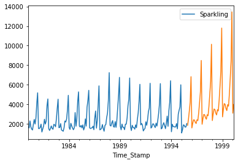

```python
plt.figure(figsize=(15,8))
df.plot()
prediction_1.plot();
```

```python
#In the below code, we have calculated the upper and lower confidence bands at 95% confidence level
#Here we are taking the multiplier to be 1.96 as we want to plot with respect to a 95% confidence intervals.
prediction_1 = pd.DataFrame({'lower_CI':prediction_1 - 1.96*np.std(fullmodel1.resid,ddof=1),
                          'prediction':prediction_1,
                          'upper_ci': prediction_1 + 1.96*np.std(fullmodel1.resid,ddof=1)})
prediction_1.head()
```

|  | lower_CI | prediction | upper_ci |
| --- | --- | --- | --- |
| 1995-08-31 | 1027.191146 | 1855.493994 | 2683.796842 |
| 1995-09-30 | 1658.733462 | 2487.036310 | 3315.339158 |
| 1995-10-31 | 2495.218486 | 3323.521334 | 4151.824182 |
| 1995-11-30 | 3397.443409 | 4225.746256 | 5054.049104 |
| 1995-12-31 | 6000.631745 | 6828.934592 | 7657.237440 |

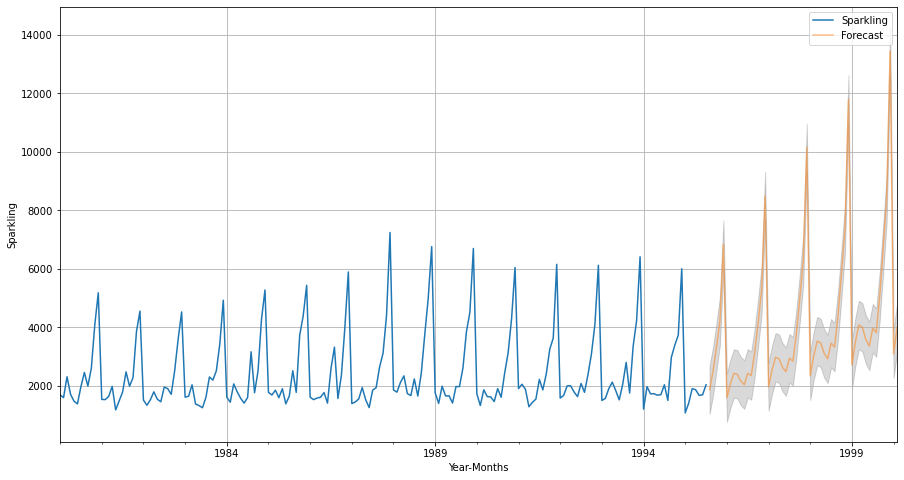

```python
# plot the forecast along with the confidence band

axis = df.plot(label='Actual', figsize=(15,8))
prediction_1['prediction'].plot(ax=axis, label='Forecast', alpha=0.5)
axis.fill_between(prediction_1.index,prediction_1['lower_CI'], prediction_1['upper_ci'], color='k', alpha=.15)
axis.set_xlabel('Year-Months')
axis.set_ylabel('Sparkling')
plt.legend(loc='best')
plt.grid()
plt.show()
```

```python
full_data_model = sm.tsa.statespace.SARIMAX(df['Sparkling'],
                                order=(2,1,3),
                                seasonal_order=(2, 0, 3, 6),
                                enforce_stationarity=False,
                                enforce_invertibility=False)
results_full_data_model = full_data_model.fit(maxiter=1000)
print(results_full_data_model.summary())
```

```
                                     SARIMAX Results
=========================================================================================
Dep. Variable:                         Sparkling   No. Observations:                  187
Model:             SARIMAX(2, 1, 3)x(2, 0, 3, 6)   Log Likelihood               -1208.895
Date:                           Sun, 26 Dec 2021   AIC                           2439.790
Time:                                   00:08:22   BIC                           2473.889
Sample:                               01-31-1980   HQIC                          2453.633
                                    - 07-31-1995
Covariance Type:                             opg
==============================================================================
                 coef    std err          z      P>|z|      [0.025      0.975]
------------------------------------------------------------------------------
ar.L1         -0.4971      1.388     -0.358      0.720      -3.218       2.224
ar.L2          0.0956      0.938      0.102      0.919      -1.742       1.933
ma.L1         -0.4549      1.377     -0.330      0.741      -3.154       2.244
ma.L2         -0.7608      0.538     -1.414      0.157      -1.815       0.293
ma.L3          0.1194      1.129      0.106      0.916      -2.094       2.333
ar.S.L6        0.0096      0.018      0.521      0.602      -0.027       0.046
ar.S.L12       1.0172      0.011     93.113      0.000       0.996       1.039
ma.S.L6       -0.3161      0.197     -1.603      0.109      -0.703       0.070
ma.S.L12      -0.8705      0.113     -7.724      0.000      -1.091      -0.650
ma.S.L18      -0.0949      0.146     -0.650      0.515      -0.381       0.191
sigma2      9.507e+04   1.84e+04      5.159      0.000     5.9e+04    1.31e+05
===================================================================================
Ljung-Box (L1) (Q):                   0.00   Jarque-Bera (JB):                31.05
Prob(Q):                              0.96   Prob(JB):                         0.00
Heteroskedasticity (H):               1.14   Skew:                             0.50
Prob(H) (two-sided):                  0.64   Kurtosis:                         4.88
===================================================================================

Warnings:
[1] Covariance matrix calculated using the outer product of gradients (complex-step).
```

```python
predicted_manual_SARIMA_full_data = results_full_data_model.get_forecast(steps=12)
```

```python
pred_full_manual_SARIMA_date = predicted_manual_SARIMA_full_data.summary_frame(alpha=0.05)
pred_full_manual_SARIMA_date.head()
```

| Sparkling | mean | mean_se | mean_ci_lower | mean_ci_upper |
| --- | --- | --- | --- | --- |
| 1995-08-31 | 1841.818408 | 376.479416 | 1103.932312 | 2579.704504 |
| 1995-09-30 | 2389.489235 | 382.059173 | 1640.667015 | 3138.311456 |
| 1995-10-31 | 3275.349057 | 382.064084 | 2526.517214 | 4024.180901 |
| 1995-11-30 | 4027.116960 | 384.284298 | 3273.933576 | 4780.300343 |
| 1995-12-31 | 6284.694861 | 384.516932 | 5531.055522 | 7038.334200 |

```python
rmse = mean_squared_error(df['Sparkling'],results_full_data_model.fittedvalues,squared=False)
print('RMSE of the Full Model',rmse)
```

```
RMSE of the Full Model 534.8228849696939
```

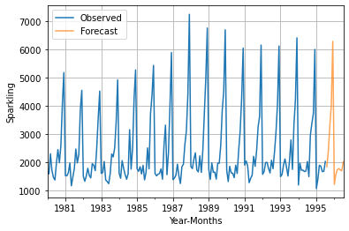

```python
axis = df['Sparkling'].plot(label='Observed')
pred_full_manual_SARIMA_date['mean'].plot(ax=axis, label='Forecast', alpha=0.7)

axis.set_xlabel('Year-Months')
axis.set_ylabel('Sparkling')
plt.legend(loc='best')
plt.grid();
```

### 10. Comment on the model thus built and report your findings and suggest the measures that the company should be taking for future sales

The recommendation to Business is to use “Triple Exponential model” to predict the wine sales for the future, as it errors minimum and predicts as good as the original sales.

Consumers get very excited about savings and appreciate discounts being passed on. Many prominent retailers also have loyalty programs or club member cards that create excitement. A club-member price brings consumers back and gives you an edge on your competition.

Need to arrange proper training to sales person, So they can convice the customer it seems to increase the sales.

In month which has low sales of wines need to arrange business events, weddings party, and summer concert series, and these are all great ways to leverage a stunning location to increase revenue.

The sales seem to be higher in the month of December and that obvious due to Christmas and new year celebrations. We can increase the production with proper advertisements will increase the sales. As per previous data sales will be decreased in beginning of the year so we need to deepdive and work on stratergies.

Sales person should post product regurly in social media will definetly increase the sales.

Wine sales is fluctuating over the month, So we need to get customer review based on that we make the decision.

There seems to be sales not increasing it is sometimes increasing and sometimes decreasing, so business has to act on quickly to improve their process and strategy to increase sale of this wine.

Wine outlet should adapt new trend to sale the wines. We need work deeply on cache advertisement,customer service and creating ambiance for customers.